# DATA ANALYSIS - KOREE PERRY (FINAL)

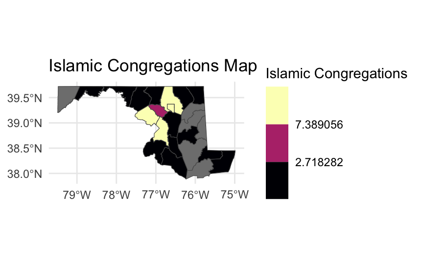

```r
islamicmd <- countydata |>
  filter(state_name == "Maryland",
         str_detect(group_name, "Muslim")) |>
  group_by(fips) |>
  summarise(
    total_congregations = sum(congregations, na.rm = TRUE)
  )

islammap <- md_all |>
  left_join(islamicmd, join_by(GEOID == fips))

ggplot(islammap) +
  geom_sf(aes(fill=total_congregations)) +
  scale_fill_viridis_b(option="magma", trans = "log") +
  theme_minimal() +
  labs(title="Islamic Congregations Map",
       fill="Islamic Congregations")
```

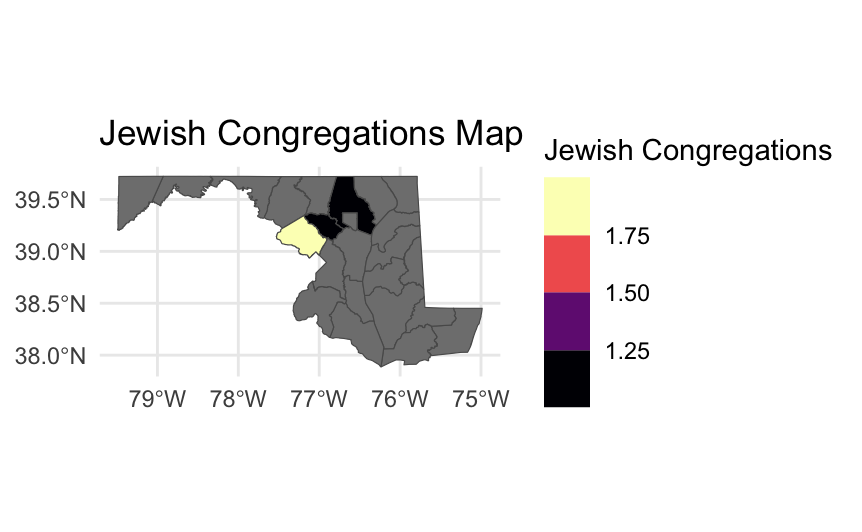

```r
judaismmd <- countydata |>
  filter(state_name == "Maryland",
         str_detect(group_name, "Jewish")) |>
  group_by(fips) |>
  summarise(
    total_congregations = sum(congregations, na.rm = TRUE)
  )

jewishmap <- md_all |>
  left_join(judaismmd, join_by(GEOID == fips))

ggplot(jewishmap) +
  geom_sf(aes(fill=total_congregations)) +
  scale_fill_viridis_b(option="magma", trans = "log") +
  theme_minimal() +
  labs(title="Jewish Congregations Map",
       fill="Jewish Congregations")
```

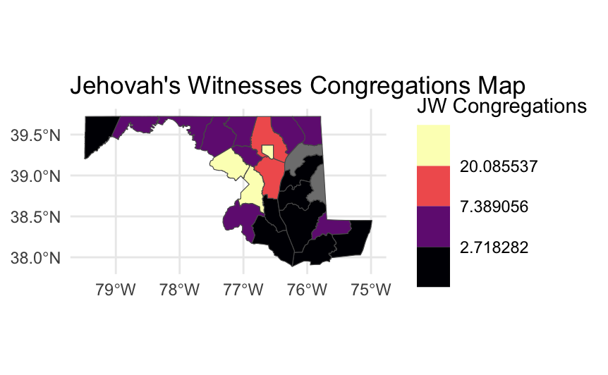

```r
jehovahmd <- countydata |>
  filter(state_name == "Maryland",
         str_detect(group_name, "Jehovah's Witnesses")) |>
  group_by(fips) |>
  summarise(
    total_congregations = sum(congregations, na.rm = TRUE)
  )

jehovahmap <- md_all |>
  left_join(jehovahmd, join_by(GEOID == fips))

ggplot(jehovahmap) +
  geom_sf(aes(fill=total_congregations)) +
  scale_fill_viridis_b(option="magma", trans = "log") +
  theme_minimal() +
  labs(title="Jehovah's Witnesses Congregations Map",
       fill="JW Congregations")
```

```r
q4bigdata <- countydata |>
  filter(state_name == "Maryland",
         str_detect(group_name, "Muslim") |
           str_detect(group_name, "Catholic")|
           str_detect(group_name, "Methodist") |
           str_detect(group_name, "Baptist")) |>
           group_by(fips, group_name) |>
  summarise(
    total_congregations = sum(congregations, na.rm = TRUE)
  )
relmapall <- md_all |>
  left_join(q4bigdata, join_by(GEOID == fips))

ggplot(q4bigdata) +
  geom_sf(aes(fill=total_congregations)) +
  scale_fill_viridis_b(option="magma", trans = "log") +
  theme_minimal() +
  labs(title="All Congregations Map",
       fill="Congregations")
```

[output not shown]

##Q5:Which groups have the highest total adherent populations compared to their number of congregations?

```r
q5adherepercong <- statedata |>
  group_by(group_name) |>
  summarise(
    total_adherents = sum(adherents, na.rm = TRUE),
    total_congregations = sum(congregations, na.rm = TRUE)
  ) |>
  mutate(
    adherents_per_cong = total_adherents / total_congregations
  ) |>
  arrange(desc(adherents_per_cong))

head(q5adherepercong, 20)
```

| group_name | total_adherents | total_congregations | adherents_per_cong |
| --- | --- | --- | --- |
| Catholic Church | 61858137 | 19405 | 3187.7422 |
| Hindu Temples | 831229 | 433 | 1919.6975 |
| Muslim Estimate | 4453908 | 2771 | 1607.3288 |
| Armenian Apostolic Church of America (Catholicosate of Cilicia) | 35565 | 32 | 1111.4062 |
| Armenian Church of North America (Catholicosate of Etchmiadzin) | 95207 | 89 | 1069.7416 |
| Orthodox Judaism | 941480 | 914 | 1030.0656 |
| Reform Judaism | 662104 | 690 | 959.5710 |
| Macedonian Orthodox Church: American Diocese | 17325 | 20 | 866.2500 |
| Conservative Judaism | 417316 | 529 | 788.8771 |
| Greek Orthodox Archdiocese of America | 375117 | 533 | 703.7842 |

[output cut: 10 more lines]

```r
##This question/code was the simplest because for the longest time I didn't know what I wanted as my fifth question, but I was interested in seeing which groups had the most adherents compared to how many congregations they also had. I think it would be interesting to see in a journalist's sense which states these groups dominate in and why? Is it because of history, people who have moved there, etc.
```

To verify my findings, comparison between the religion census data and the additional demographic data given by the U.S. Census Bureau as well as other reporting on religious demigraphic in Maryland and the states surrounding it. Interviewing religious leaders, historians, residents and more in counties where faiths at the local level differ from the ones dominating the state. I’d also like to verify if the clustering of different congregations, once put on one full map of Maryland, shows the patterns of historical migration onto the land or different varying population patterns. ```